# Multiple Logistic Regression Modeling - Stroke Prediction

Chloe Winters

10/6/2024

```r
knitr::opts_chunk$set(echo = TRUE,
                      warnings = FALSE,
                      messages = FALSE,
                      results = TRUE
                      )

   library(knitr)
   library(pander)
   library(mlbench)
```

# 1 Introduction

This assignment will further analyse the stroke prediction data set that was used in the previous assignment. This time there will also be analysis done on more than just the stroke and bmi variables.

# 2 Materials

## 2.1 Data Set

According to the World Health Organization (WHO) 11% of deaths worldwide can be attributed to strokes, making strokes the second leading cause of death across the world. Since strokes are a leading cause of death, this data set was created in order to look at aspects of patients, like their age, gender, lifestyle choices, and history of disease, to help predict their likelihood of having a stroke. There is not additional information available about who collected this data or the data collection methods.

```r
url="https://ChloeWinters79.github.io/STA321/Data/healthcare-dataset-stroke-data.csv"
stroke.0 = read.csv(url, header = TRUE)
```

The data set, called stroke prediction, has 12 variables and they are as follows

## 2.2 Data Cleaning

The variable BMI had missing variables inputted as the characters “N/A” making BMI a character variable instead of a numeric variable. In order to properly convert BMI into a numeric variable all observations with a BMI of “N/A” needed to be removed. This resulted in the removal of 201 observations from the data set. Since the data set has 5,110 observations this is roughly 4% of the original data set. Considering that this removal is a small proportion of the original data set the removal should not have a significant impact on the results.

For the analysis, the variable ID was also removed because it does not have a significant impact on the data and is not needed for the analysis that is going to be conducted on the data set.

```r
stroke.1 = subset(stroke.0, bmi != "N/A")
stroke.1$bmi = as.numeric(stroke.1$bmi)
stroke = subset(stroke.1, select = -c(id))
stroke$age = round(stroke$age, digits = 0)
```

# 3 Methodology & Analysis

## 3.1 Exploratory Data Analysis

```r
library(psych)
```

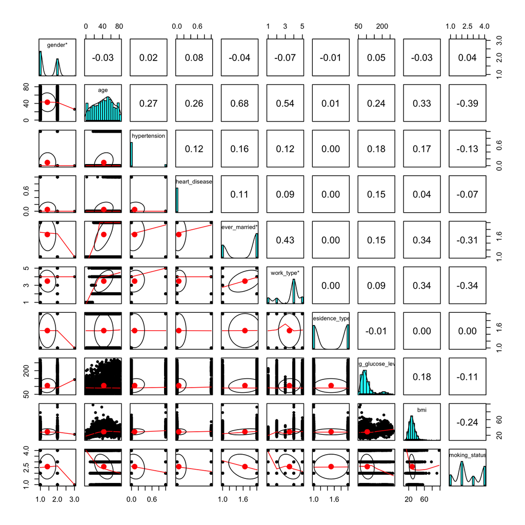

```r
pairs.panels(stroke[, -11],
             method = "pearson", # correlation method
             hist.col = "cyan",
             density = TRUE,  # show density plots
             ellipses = TRUE # show correlation ellipses
             )
```

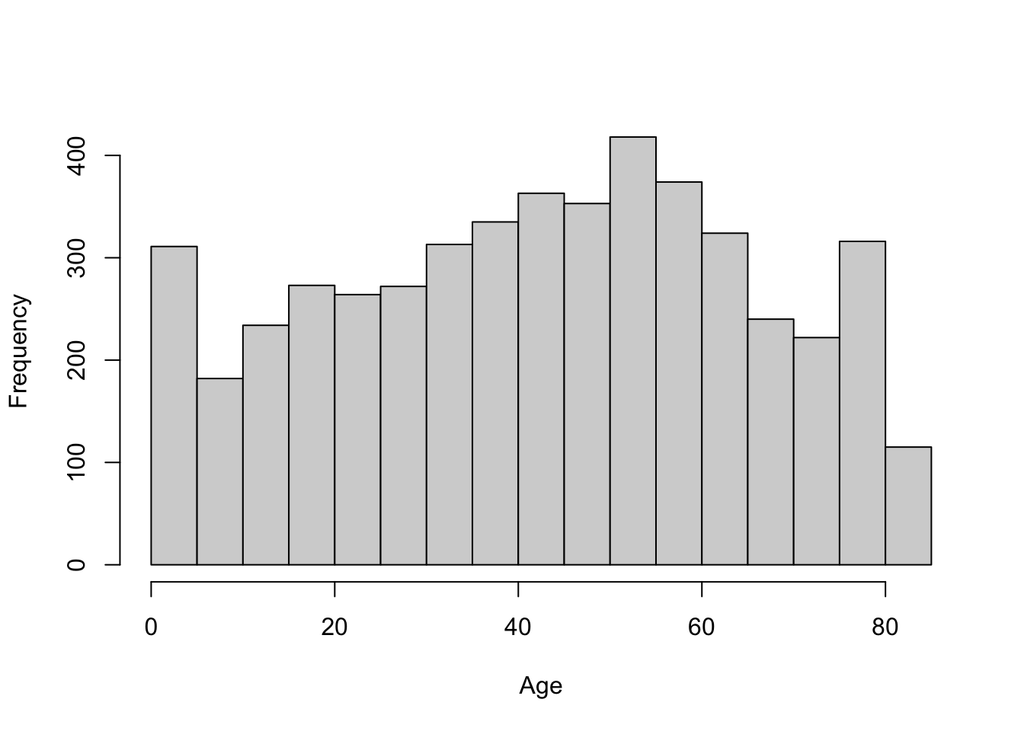

```r
par(mfrow=c(1,1))
hist(stroke$age, xlab = "Age", main = "")
```

Considering the above frequency distribution, the choice was made to discretize the variable age.

```r
age = stroke$age

grp.age = age
grp.age[age %in% c(0:5)] = "0-5"
grp.age[age %in% c(6:15)] = "06-15"
grp.age[age %in% c(16:25)] = "16-25"
grp.age[age %in% c(26:35)] = "26-35"
grp.age[age %in% c(36:45)] = "36-45"
grp.age[age %in% c(46:55)] = "46-55"
grp.age[age %in% c(56:65)] = "56-65"
grp.age[age %in% c(66:75)] = "66-75"
grp.age[age %in% c(76:1000)] = "75+"

stroke$grp.age = grp.age
```

A moderate correlation was present in the pairs, age vs ever_married, age vs work_type and ever_married vs work_type. No variable dropping will currently be taking place, but there will be an automatic variable selection to remove any redundant variables. Additionally, at this time there will be no transformation of the variables since the goal of this assignment is association analysis.

The U.S Center for Disease Control and Prevention (CDC) identifies some of the major risk factors for a stroke to be high blood pressure (hypertension), heart disease, and diabetes (avg_glucose_level). Since these variables, hypertension, heart_disease, and avg_glucose_level, carry a practical importance they will be included in the final model.

## 3.2 Building the Multiple Logistic Regression Model

Taking into consideration the above exploratory data analysis, it is time to build the full and reduced models.

```r
full.model = glm(stroke ~gender+grp.age+hypertension+heart_disease+ever_married+work_type+Residence_type+avg_glucose_level+bmi+smoking_status,
          family = binomial(link = "logit"),  #  logit(p) = log(p/(1-p))!
          data = stroke)
kable(summary(full.model)$coef,
      caption="Summary of inferential statistics of the full model")
```

Summary of inferential statistics of the full model

|  | Estimate | Std. Error | z value | Pr(>\|z\|) |
| --- | --- | --- | --- | --- |
| (Intercept) | -20.7405280 | 1.004302e+03 | -0.0206517 | 0.9835235 |
| genderMale | -0.0186686 | 1.541222e-01 | -0.1211288 | 0.9035890 |
| genderOther | -14.6030849 | 1.773037e+04 | -0.0008236 | 0.9993428 |
| grp.age06-15 | 14.6630451 | 1.004303e+03 | 0.0146002 | 0.9883511 |
| grp.age16-25 | 4.1402951 | 1.190018e+03 | 0.0034792 | 0.9972240 |
| grp.age26-35 | 26.3189133 | 1.189077e+03 | 0.0221339 | 0.9823412 |
| grp.age36-45 | 28.3688788 | 1.189077e+03 | 0.0238579 | 0.9809660 |
| grp.age46-55 | 29.2371272 | 1.189077e+03 | 0.0245881 | 0.9803835 |
| grp.age56-65 | 29.8258818 | 1.189077e+03 | 0.0250832 | 0.9799886 |
| grp.age66-75 | 30.4128529 | 1.189077e+03 | 0.0255769 | 0.9795948 |
| grp.age75+ | 31.0878563 | 1.189077e+03 | 0.0261445 | 0.9791421 |
| hypertension | 0.5356820 | 1.742671e-01 | 3.0739138 | 0.0021127 |
| heart_disease | 0.3882515 | 2.062973e-01 | 1.8820004 | 0.0598360 |
| ever_marriedYes | -0.2365928 | 2.495044e-01 | -0.9482511 | 0.3430016 |
| work_typeGovt_job | -12.3928080 | 6.366172e+02 | -0.0194667 | 0.9844688 |
| work_typeNever_worked | -13.6350513 | 3.474278e+03 | -0.0039246 | 0.9968687 |
| work_typePrivate | -12.2157434 | 6.366171e+02 | -0.0191885 | 0.9846907 |
| work_typeSelf-employed | -12.6123236 | 6.366172e+02 | -0.0198115 | 0.9841938 |
| Residence_typeUrban | 0.0052748 | 1.499718e-01 | 0.0351718 | 0.9719428 |
| avg_glucose_level | 0.0046349 | 1.296900e-03 | 3.5737474 | 0.0003519 |
| bmi | 0.0004486 | 1.205730e-02 | 0.0372072 | 0.9703198 |
| smoking_statusnever smoked | -0.0710238 | 1.886445e-01 | -0.3764957 | 0.7065484 |
| smoking_statussmokes | 0.2769972 | 2.290604e-01 | 1.2092762 | 0.2265567 |
| smoking_statusUnknown | -0.2677627 | 2.468259e-01 | -1.0848239 | 0.2779997 |

```r
reduced.model = glm(stroke ~ hypertension + heart_disease + avg_glucose_level,
          family = binomial(link = "logit"),  # logit(p) = log(p/(1-p))!
          data = stroke)
kable(summary(reduced.model)$coef,
      caption="Summary of inferential statistics of the reduced model")
```

Summary of inferential statistics of the reduced model

|  | Estimate | Std. Error | z value | Pr(>\|z\|) |
| --- | --- | --- | --- | --- |
| (Intercept) | -4.3710827 | 0.1767819 | -24.725845 | 0 |
| hypertension | 1.1124253 | 0.1721474 | 6.462050 | 0 |
| heart_disease | 1.2049077 | 0.2025267 | 5.949376 | 0 |
| avg_glucose_level | 0.0081366 | 0.0012920 | 6.297835 | 0 |

```r
library(MASS)
final.model.forward = stepAIC(reduced.model,
                      scope = list(lower=formula(reduced.model),upper=formula(full.model)),
                      direction = "forward",   # forward selection
                      trace = 0   # do not show the details
                      )
kable(summary(final.model.forward)$coef,
      caption="Summary of inferential statistics of the final model")
```

Summary of inferential statistics of the final model

|  | Estimate | Std. Error | z value | Pr(>\|z\|) |
| --- | --- | --- | --- | --- |
| (Intercept) | -20.0103335 | 609.1242745 | -0.0328510 | 0.9737934 |
| hypertension | 0.5456806 | 0.1719664 | 3.1731804 | 0.0015078 |
| heart_disease | 0.4421000 | 0.2025912 | 2.1822267 | 0.0290928 |
| avg_glucose_level | 0.0046696 | 0.0012555 | 3.7192195 | 0.0001998 |
| grp.age06-15 | 13.5308503 | 609.1250853 | 0.0222136 | 0.9822776 |
| grp.age16-25 | -0.0049449 | 765.3919971 | -0.0000065 | 0.9999948 |
| grp.age26-35 | 13.1807011 | 609.1250847 | 0.0216387 | 0.9827361 |
| grp.age36-45 | 15.1378328 | 609.1243553 | 0.0248518 | 0.9801732 |
| grp.age46-55 | 15.9822337 | 609.1242979 | 0.0262380 | 0.9790675 |
| grp.age56-65 | 16.5466181 | 609.1242860 | 0.0271646 | 0.9783284 |
| grp.age66-75 | 17.0738110 | 609.1242863 | 0.0280301 | 0.9776381 |
| grp.age75+ | 17.6901999 | 609.1242804 | 0.0290420 | 0.9768311 |

```r
global.measure=function(s.logit){
dev.resid = s.logit$deviance
dev.0.resid = s.logit$null.deviance
aic = s.logit$aic
goodness = cbind(Deviance.residual =dev.resid, Null.Deviance.Residual = dev.0.resid,
      AIC = aic)
goodness
}
goodness=rbind(full.model = global.measure(full.model),
      reduced.model=global.measure(reduced.model),
      final.model=global.measure(final.model.forward))
row.names(goodness) = c("full.model", "reduced.model", "final.model")
kable(goodness, caption ="Comparison of global goodness-of-fit statistics")
```

Comparison of global goodness-of-fit statistics

|  | Deviance.residual | Null.Deviance.Residual | AIC |
| --- | --- | --- | --- |
| full.model | 1353.419 | 1728.386 | 1401.419 |
| reduced.model | 1580.611 | 1728.386 | 1588.611 |
| final.model | 1364.183 | 1728.386 | 1388.183 |

## 3.3 Final Model

While conducting the exploratory analysis there appeared to be pairs of variables that seemed to be linearly correlated. After the automatic variable selection, ever_married and work_type dropped from the final model. Additionally, age was turned into a grouped variable, so the variable age was not included in the model, while grp.age was included and was not dropped from the final model. However, none of the individual grouped ages look to be statistically significant. The variables that have statistical significance are the ones that make up the reduced model. Considering that the reduced model has the highest AIC of the models, despite not being statistically significant we will keep all the grp.age variables in the model since the final model produced the best AIC.

```r
model.coef.stats = summary(final.model.forward)$coef
odds.ratio = exp(coef(final.model.forward))
out.stats = cbind(model.coef.stats, odds.ratio = odds.ratio)
kable(out.stats,caption = "Summary Stats with Odds Ratios")
```

Summary Stats with Odds Ratios

|  | Estimate | Std. Error | z value | Pr(>\|z\|) | odds.ratio |
| --- | --- | --- | --- | --- | --- |
| (Intercept) | -20.0103335 | 609.1242745 | -0.0328510 | 0.9737934 | 0.000000e+00 |
| hypertension | 0.5456806 | 0.1719664 | 3.1731804 | 0.0015078 | 1.725782e+00 |
| heart_disease | 0.4421000 | 0.2025912 | 2.1822267 | 0.0290928 | 1.555971e+00 |
| avg_glucose_level | 0.0046696 | 0.0012555 | 3.7192195 | 0.0001998 | 1.004681e+00 |
| grp.age06-15 | 13.5308503 | 609.1250853 | 0.0222136 | 0.9822776 | 7.522698e+05 |
| grp.age16-25 | -0.0049449 | 765.3919971 | -0.0000065 | 0.9999948 | 9.950673e-01 |
| grp.age26-35 | 13.1807011 | 609.1250847 | 0.0216387 | 0.9827361 | 5.300364e+05 |
| grp.age36-45 | 15.1378328 | 609.1243553 | 0.0248518 | 0.9801732 | 3.752124e+06 |
| grp.age46-55 | 15.9822337 | 609.1242979 | 0.0262380 | 0.9790675 | 8.729632e+06 |
| grp.age56-65 | 16.5466181 | 609.1242860 | 0.0271646 | 0.9783284 | 1.534988e+07 |
| grp.age66-75 | 17.0738110 | 609.1242863 | 0.0280301 | 0.9776381 | 2.600530e+07 |
| grp.age75+ | 17.6901999 | 609.1242804 | 0.0290420 | 0.9768311 | 4.816773e+07 |

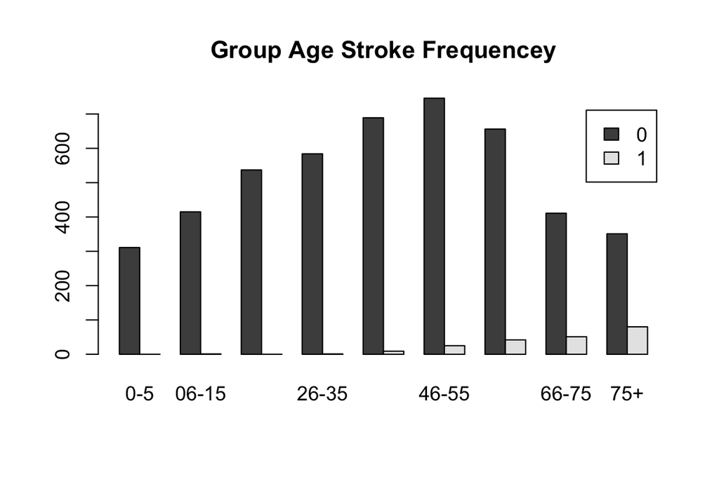

```r
count <- table(stroke$stroke, stroke$grp.age)
barplot(height = count, beside = TRUE, legend = rownames(count), main = "Group Age Stroke Frequencey")
```

The graph clearly depicts how small the likelihood of having a stroke is in the baseline group, and shows how the frequency goes from roughly 0 in the baseline group to almost 100 in the 75+ group. This makes it more clear to why the odds ratios for the grp.age variable is so high.

# 4 Results & Conclusion

This assignment looked into the association between potential risk factors for a stroke. The original data set consisted of 5 categorical variables, and 7 numerical variables. Of the 7 numerical variables 1 of them was a patient ID number which was removed from the data set for the analysis. Of the remaining 6 numerical variables, 3 of them were binary variables. After conducting the exploratory data analysis, the decision was made to regroup the sparse discrete variable age and assign a dummy variable for the associated variable. The new variable was called grp.age and was used in the model search process.

In the model search process, a decision was made to keep the variables hypertension, heart_disease, and avg_glucose_level, regardless of their statistical significance, because they are associated with leading causes of strokes. However, all three variables were statistically significant and ended up in the final model. The variable grp.age was in the only other variable in the final model, but was not considered statistically significant. However, removing the grp.age variable would have resulted in the final model becoming equivalent to the reduced model. Since the reduced model had the least desirable AIC and the final model with grp.age included had the most desirable AIC, the choice was made not to remove grp.age.

# 5 General Discussion

When conducting analysis on this data set a concern was raised. Looking at the odds ratio and seeing the odds of a certain age group having a stroke being 8.729632e+06 higher than the baseline group can be incredibly misleading without supported by the proper context. Especially paired next to the odds ratio for having a stroke for a patient with heart disease being 1.555971 it makes age look like a much more influential factor on strokes than it actually is. If a statistic like this was given to someone with little to no context it could start an uproar. It could incorrectly lead people to believe that age is such an influential aspect on people having a stroke, that things like diabetes and heart disease do not matter in comparison. This could result in people not prioritizing their health because they think their age is what will cause them to have a stroke and they have no control over their age, so why not do whatever they want in the meantime.

If this was for an official publish article that would be referenced in academic papers, it would be beneficial to rework the grp.age variable. This way even without proper context the odds ratio for grp.age would not portray being significantly larger than the odds ratios for heart disease, hypertension, and avg_glucose_level.

# 6 References

CDC. (2024, April 29). Risk Factors for Stroke. Stroke. https://www.cdc.gov/stroke/risk-factors/index.html

Philadelphia, T. C. H. of. (2014, June 30). Pediatric Stroke. Www.chop.edu. https://www.chop.edu/conditions-diseases/pediatric-stroke

STROKE RISK FACTORS WEIGHT UNDERSTANDING WEIGHT AND STROKE. https://www.world-stroke.org/assets/downloads/WSO_DontBeTheOne_PI_Leaflets_-_WEIGHT.pdf